# Known map experiment - average navigation time

We are analyzing if offloading any of the three functionalities (i.e., localisation, navigation and object recognition) has a statistically significant effect on the average navigation time. Fist, install and load the required libraries:

```r
if (!require('tidyverse')) install.packages('tidyverse', dependencies = TRUE); library('tidyverse')
if (!require('ggpubr')) install.packages('ggpubr', dependencies = TRUE); library('ggpubr')
if (!require('rstatix')) install.packages('rstatix', dependencies = TRUE); library('rstatix')
if (!require('ggplot2')) install.packages('ggplot2', dependencies = TRUE); library('ggplot2')
if (!require('lmPerm')) install.packages('lmPerm', dependencies = TRUE); library('lmPerm')
if (!require('emmeans')) install.packages('emmeans', dependencies = TRUE); library('emmeans')
```

Next, load the experiment results from the csv file:

```r
data <- read.csv(file = '../../raw_data/known_map_experiment/run_table.csv')
data$avg_navigation_time_s <- (data$avg_goal_sending_delay_ms + data$avg_goal_processing_s*1000 + data$avg_nav_result_delay_ms)/1000
data <- subset(data, select = c(X__run_id, amcl_offloaded, navigation_offloaded, obj_recognition_offloaded, avg_navigation_time_s))
data$amcl_offloaded <- as.factor(data$amcl_offloaded)
data$navigation_offloaded <- as.factor(data$navigation_offloaded)
data$obj_recognition_offloaded <- as.factor(data$obj_recognition_offloaded)
data$avg_navigation_time_s <- as.numeric(data$avg_navigation_time_s)
```

Mean and standard deviation of the average navigation time for each treatment are displayed in the summary below:

```r
data %>%
  group_by(amcl_offloaded, navigation_offloaded, obj_recognition_offloaded) %>%
  get_summary_stats(avg_navigation_time_s, type = "mean_sd")
```

| amcl_offloaded | navigation_offloaded | obj_recognition_offloaded | variable | n | mean | sd |
| --- | --- | --- | --- | --- | --- | --- |
| false | false | false | avg_navigation_time_s | 10 | 9.879 | 0.327 |
| false | false | true | avg_navigation_time_s | 10 | 9.418 | 0.232 |
| false | true | false | avg_navigation_time_s | 10 | 10.139 | 0.796 |
| false | true | true | avg_navigation_time_s | 10 | 9.386 | 0.161 |
| true | false | false | avg_navigation_time_s | 10 | 9.873 | 0.287 |
| true | false | true | avg_navigation_time_s | 10 | 9.459 | 0.348 |
| true | true | false | avg_navigation_time_s | 10 | 9.789 | 0.363 |
| true | true | true | avg_navigation_time_s | 10 | 9.529 | 0.261 |

# Three-Way ANOVA test

Since there are three independent variables in the experiment, we opt for three-way ANOVA test. First, we need to check if all assumptions for performing the test are met. The fist assumption of having independent observations is met inherently according to the way the experiment itself is conducted.

## No extreme outliers assumption

Next, we need to check if there are any extreme outliers:

```r
data %>%
  group_by(amcl_offloaded, navigation_offloaded, obj_recognition_offloaded) %>%
  identify_outliers(avg_navigation_time_s)
```

| amcl_offloaded | navigation_offloaded | obj_recognition_offloaded | X__run_id | avg_navigation_time_s | is.outlier | is.extreme |
| --- | --- | --- | --- | --- | --- | --- |
| false | true | false | run_54 | 12.205917 | TRUE | TRUE |
| true | false | false | run_48 | 9.346333 | TRUE | FALSE |
| true | false | false | run_55 | 10.358417 | TRUE | FALSE |
| true | false | true | run_44 | 10.184667 | TRUE | FALSE |
| true | true | false | run_3 | 10.712167 | TRUE | TRUE |
| true | true | false | run_12 | 9.265333 | TRUE | TRUE |

The results show that there six outliers, for runs 54, 48, 55, 44, 3 and 12, respectfully, while runs 54, 3 and 12 represent extreme outliers. We should remove the said runs from the dataset, but we can also leave them if we believe that they will not have a significant effect on the obtained results. Let us make an alternative dataset with the extreme outliers being removed:

```r
data_without_outliers <- data
data_without_outliers <- data_without_outliers[!(data_without_outliers$X__run_id == 'run_54'),]
data_without_outliers <- data_without_outliers[!(data_without_outliers$X__run_id == 'run_3'),]
data_without_outliers <- data_without_outliers[!(data_without_outliers$X__run_id == 'run_12'),]
```

## Normality assumption by analyzing the model residuals

The first way to check normality assumption is by analyzing the model residuals:

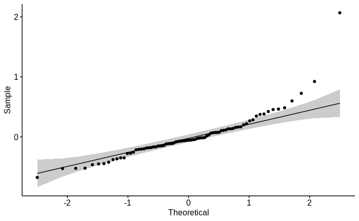

```r
model  <- lm(avg_navigation_time_s ~ amcl_offloaded*navigation_offloaded*obj_recognition_offloaded, data = data)
ggqqplot(residuals(model))
```

The QQ plot in the figure above shows that most of the residuals are scattered around the reference line, especially around the edges, thus we cannot assume that the residuals are normally distributed. We will complement the QQ plot with Shapiro-Wilk test to conclude if the normality is indeed satisfied:

```r
shapiro_test(residuals(model)) %>%
  add_significance()
```

| variable | statistic | p.value | p.value.signif |
| --- | --- | --- | --- |
| residuals(model) | 0.8356238 | 5.492343e-08 | **** |

The p-value of $5.49 \cdot 10^{-8}$ shows that we can reject $H_0$, which states that the data is indeed normally distributed. We can conclude that the normally constraint is not satisfied. If we try with the dataset that does not contain outliers:

```r
model_without_outliers  <- lm(avg_navigation_time_s ~ amcl_offloaded*navigation_offloaded*obj_recognition_offloaded, data = data_without_outliers)
shapiro_test(residuals(model_without_outliers)) %>%
  add_significance()
```

| variable | statistic | p.value | p.value.signif |
| --- | --- | --- | --- |
| residuals(model_without_outliers) | 0.9746549 | 0.1266979 | ns |

we get very different results that suggest that normality of residuals assumption holds, since p-value is now greater than 0.05.

## Normality assumption by each group

The other way to check normality is by analyzing if samples for each possible treatment combination are normally distributed:

```r
data %>%
  group_by(amcl_offloaded, navigation_offloaded, obj_recognition_offloaded) %>%
  shapiro_test(avg_navigation_time_s) %>%
  add_significance()
```

| amcl_offloaded | navigation_offloaded | obj_recognition_offloaded | variable | statistic | p | p.signif |
| --- | --- | --- | --- | --- | --- | --- |
| false | false | false | avg_navigation_time_s | 0.9512904 | 0.683783902 | ns |
| false | false | true | avg_navigation_time_s | 0.9421642 | 0.577336896 | ns |
| false | true | false | avg_navigation_time_s | 0.7348813 | 0.002336052 | ** |
| false | true | true | avg_navigation_time_s | 0.8959348 | 0.197580902 | ns |
| true | false | false | avg_navigation_time_s | 0.9541893 | 0.718128703 | ns |
| true | false | true | avg_navigation_time_s | 0.8726467 | 0.107312039 | ns |
| true | true | false | avg_navigation_time_s | 0.7470816 | 0.003288296 | ** |
| true | true | true | avg_navigation_time_s | 0.9584675 | 0.768265872 | ns |

Shapiro-Wilk test per each group yields p-value higher than `0.05` for all groups but two. If we execute the test on the dataset without extreme outliers:

```r
data_without_outliers %>%
  group_by(amcl_offloaded, navigation_offloaded, obj_recognition_offloaded) %>%
  shapiro_test(avg_navigation_time_s) %>%
  add_significance()
```

| amcl_offloaded | navigation_offloaded | obj_recognition_offloaded | variable | statistic | p | p.signif |
| --- | --- | --- | --- | --- | --- | --- |
| false | false | false | avg_navigation_time_s | 0.9512904 | 0.6837839 | ns |
| false | false | true | avg_navigation_time_s | 0.9421642 | 0.5773369 | ns |
| false | true | false | avg_navigation_time_s | 0.9424271 | 0.6076680 | ns |
| false | true | true | avg_navigation_time_s | 0.8959348 | 0.1975809 | ns |
| true | false | false | avg_navigation_time_s | 0.9541893 | 0.7181287 | ns |
| true | false | true | avg_navigation_time_s | 0.8726467 | 0.1073120 | ns |
| true | true | false | avg_navigation_time_s | 0.9323921 | 0.5380986 | ns |
| true | true | true | avg_navigation_time_s | 0.9584675 | 0.7682659 | ns |

all groups seem to be normally distributed. The QQ-plots per group are depicted below, where the data points for some groups seem to be slightly scattered around the reference line:

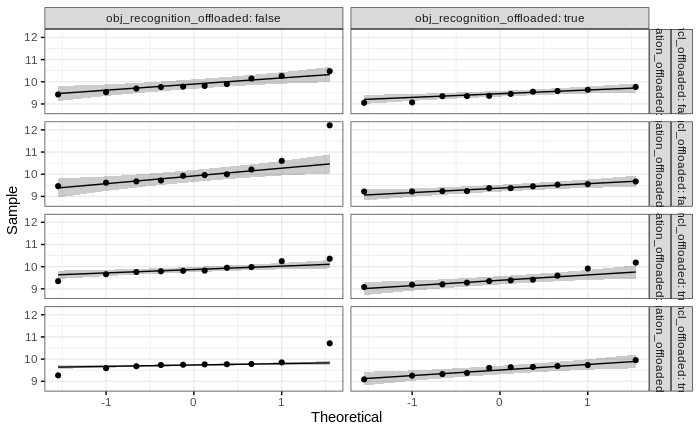

```r
ggqqplot(data, "avg_navigation_time_s", ggtheme = theme_bw()) +
  facet_grid(amcl_offloaded + navigation_offloaded ~ obj_recognition_offloaded, labeller = "label_both")
```

## Homogeneity of variance assumption

Homogeneity of variance assumption can be checked via Levene’s test:

```r
data %>%
  levene_test(avg_navigation_time_s ~ amcl_offloaded*navigation_offloaded*obj_recognition_offloaded) %>%
  add_significance()
```

| df1 | df2 | statistic | p | p.signif |
| --- | --- | --- | --- | --- |
| 7 | 72 | 1.033361 | 0.415694 | ns |

Since the p-value is higher than `0.05`, the result of the Levene’s test is not statistically significant, hence the assumption for homogeneity of variance holds. If we try the same test on data frame without outliers:

```r
data_without_outliers %>%
  levene_test(avg_navigation_time_s ~ amcl_offloaded*navigation_offloaded*obj_recognition_offloaded) %>%
  add_significance()
```

| df1 | df2 | statistic | p | p.signif |
| --- | --- | --- | --- | --- |
| 7 | 69 | 1.176298 | 0.3277773 | ns |

we come to the same conlusion that homogeneity of variances assumption holds. Since we got normality assumption satisfied for data without extreme outliers, but not in the full dataset, we will proceed with three-way ANOVA test for both datasets to compare the results.

## Test execution

Since all the assumptions for applying three-way ANOVA test on dataset without outliers hold, we can proceed with the computation:

```r
data_without_outliers %>%
  anova_test(avg_navigation_time_s ~ amcl_offloaded*navigation_offloaded*obj_recognition_offloaded)
```

```
Coefficient covariances computed by hccm()
```

```
ANOVA Table (type II tests)

                                                         Effect DFn DFd      F        p p<.05      ges
1                                                amcl_offloaded   1  69  0.020 8.89e-01       0.000284
2                                          navigation_offloaded   1  69  0.048 8.28e-01       0.000691
3                                     obj_recognition_offloaded   1  69 42.586 9.52e-09     * 0.382000
4                           amcl_offloaded:navigation_offloaded   1  69  0.040 8.42e-01       0.000583
5                      amcl_offloaded:obj_recognition_offloaded   1  69  1.966 1.65e-01       0.028000
6                navigation_offloaded:obj_recognition_offloaded   1  69  0.307 5.81e-01       0.004000
7 amcl_offloaded:navigation_offloaded:obj_recognition_offloaded   1  69  1.149 2.88e-01       0.016000
```

The results of the test do not show statistically significant three-way interaction nor any statistically significant two-way interactions between independent variables. However, there is a statistically significant main effect of object recognition on average navigation time, respectively. If we compare this result with the one for full dataset:

```r
data %>%
  anova_test(avg_navigation_time_s ~ amcl_offloaded*navigation_offloaded*obj_recognition_offloaded)
```

```
Coefficient covariances computed by hccm()
```

```
ANOVA Table (type II tests)

                                                         Effect DFn DFd      F        p p<.05   ges
1                                                amcl_offloaded   1  72  0.243 6.24e-01       0.003
2                                          navigation_offloaded   1  72  0.375 5.42e-01       0.005
3                                     obj_recognition_offloaded   1  72 29.112 8.31e-07     * 0.288
4                           amcl_offloaded:navigation_offloaded   1  72  0.475 4.93e-01       0.007
5                      amcl_offloaded:obj_recognition_offloaded   1  72  2.384 1.27e-01       0.032
6                navigation_offloaded:obj_recognition_offloaded   1  72  0.154 6.96e-01       0.002
7 amcl_offloaded:navigation_offloaded:obj_recognition_offloaded   1  72  1.630 2.06e-01       0.022
```

we get the same result. If we try non-parametric alternative to three-way ANOVA, i.e., permutation test:

```r
summary(aovp(avg_navigation_time_s ~ amcl_offloaded*navigation_offloaded*obj_recognition_offloaded, data = data, perm="Prob", maxIter=500000, nCycle=100, Ca=0.001))
```

```
[1] "Settings:  unique SS "
Component 1 :
                                                              Df R Sum Sq R Mean Sq   Iter Pr(Prob)
amcl_offloaded                                                 1   0.0371    0.0371 500000   0.6390
navigation_offloaded                                           1   0.0574    0.0574 500000   0.5624
amcl_offloaded:navigation_offloaded                            1   0.0727    0.0727 500000   0.5131
obj_recognition_offloaded                                      1   4.4532    4.4532 500000   <2e-16 ***
amcl_offloaded:obj_recognition_offloaded                       1   0.3646    0.3646 500000   0.1231
navigation_offloaded:obj_recognition_offloaded                 1   0.0235    0.0235     51   1.0000
amcl_offloaded:navigation_offloaded:obj_recognition_offloaded  1   0.2493    0.2493 500000   0.2149
Residuals                                                     72  11.0135    0.1530
---
Signif. codes:  0 ‘***’ 0.001 ‘**’ 0.01 ‘*’ 0.05 ‘.’ 0.1 ‘ ’ 1
```

```r
res.aov <- aov(avg_navigation_time_s ~ amcl_offloaded*navigation_offloaded*obj_recognition_offloaded, data = data)
eta_squared(res.aov)
```

```
                                               amcl_offloaded                                          navigation_offloaded
                                                  0.002280417                                                   0.003524995
                                    obj_recognition_offloaded                           amcl_offloaded:navigation_offloaded
                                                  0.273683236                                                   0.004467148
                     amcl_offloaded:obj_recognition_offloaded                navigation_offloaded:obj_recognition_offloaded
                                                  0.022410293                                                   0.001445207
amcl_offloaded:navigation_offloaded:obj_recognition_offloaded
                                                  0.015323989
```

# Results

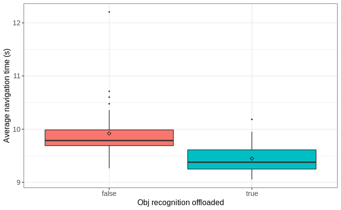

```r
#pdf(file = "../../figures/known_map_experiment/navigation-time-1.pdf")

ggplot(data, aes(x = obj_recognition_offloaded, y = avg_navigation_time_s, fill = obj_recognition_offloaded)) +
  theme_bw() +
  geom_boxplot(width = 0.9, outlier.size = 0.5) +
  stat_summary(fun = mean, color = 'black', geom = 'point', shape = 5) +
  labs(x = "Obj recognition offloaded", y = "Average navigation time (s)") +
  theme(legend.position = "none") +
  theme(
    axis.title.x = element_text(size = 12, family = 'sans'),
    axis.title.y = element_text(size = 12, family = 'sans'),
    axis.text.x = element_text(size = 11, family = 'sans'),
    axis.text.y = element_text(size = 11, family = 'sans')
  )
```

```r
#dev.off()
```